# Growth Curve Analysis

Dan Mirman

22 May 2020

# Schedule

Schedule

| Time | Topic | Data set(s) |
| --- | --- | --- |
| 9-9:30am | Introduction | Visual Search |
| 9:30-10am | Exercise | WISQARS, Naming Recovery |
| 10-10:45am | Non-linear change | Word Learning |
| 10:45-11:30am | Exercise | CP |
| 11:30-noon | Within-subject effects | Target Fixation |
| 12-1pm | Lunch break; Exercise | Az |
| 1-1:45pm | Logistic GCA; Exercise | Target Fixation; Word Learning |
| 1:45-2:30pm | Individual Differences | Deviant Behavior; School Mental Health |
| 2:30-3pm | Exercise; Open Q&A | NA |

# Preliminaries

### Packages

- `tidyverse`, `patchwork`: data management and graphing data and model fits
- `lme4`, `lmerTest`: fitting growth curve models and estimating p-values
- [`psy811`](http://github.com/dmirman/psy811): example data sets and helper functions. To install: `devtools::install_github("dmirman/psy811")`

### Pre-processing eye-tracking data

I recommend our `gazeR` package: http://github.com/dmirman/gazer. GazeR also contains the GCA helper functions (`psy811` has more example data sets so we’ll use that one for this workshop).

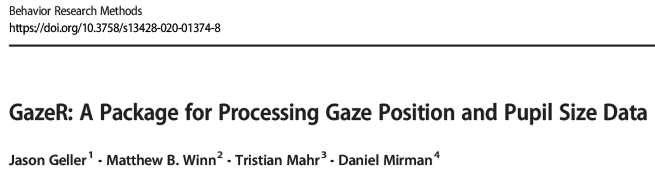

https://rdcu.be/b3z6q

# What are time course data?

- Longitudinal data
- Repeated observations
- Example: Height tracking
- Specific case of “repeated measures” or “nested” data

# Two key features

**Nested data are not independent**

- A child that is taller-than-average at time *t*, is likely to be taller-than-average at time *t+1*
- Non-independence is related to individual differences
- Nesting can happen on multiple levels: children within families or hospitals

# Two key features

**Nested data are not independent**

- A child that is taller-than-average at time *t*, is likely to be taller-than-average at time *t+1*
- Non-independence is related to individual differences
- Nesting can happen on multiple levels: children within families or hospitals

**Related by continuous variable** (i.e., time, but could be [letter] size, number of distractors, etc.)

- Ought to model this variable as continuous
- Can quantify trajectories/shapes of change

# Gradual change

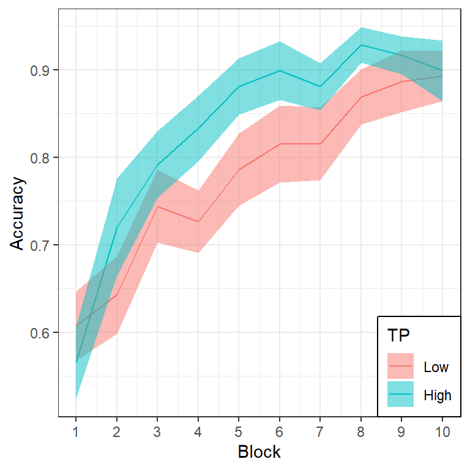

- Novel word learning is faster for high TP than low TP words
- But, t-test on overall mean accuracy is marginal (p=0.096)
- Repeated measures ANOVA shows main effect of Block, marginal effect of TP, and no interaction (F<1)
- Block-by-block t-test significant only in block 4 and marginal in block 5

# Replication crisis

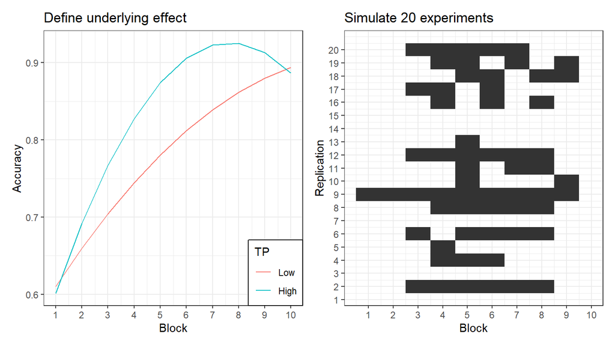

- 5/20 replications had no significant effect in any block
- **Solution**: Use a regression-based approach to analyze the full trajectory

# Linear regression: A brief review

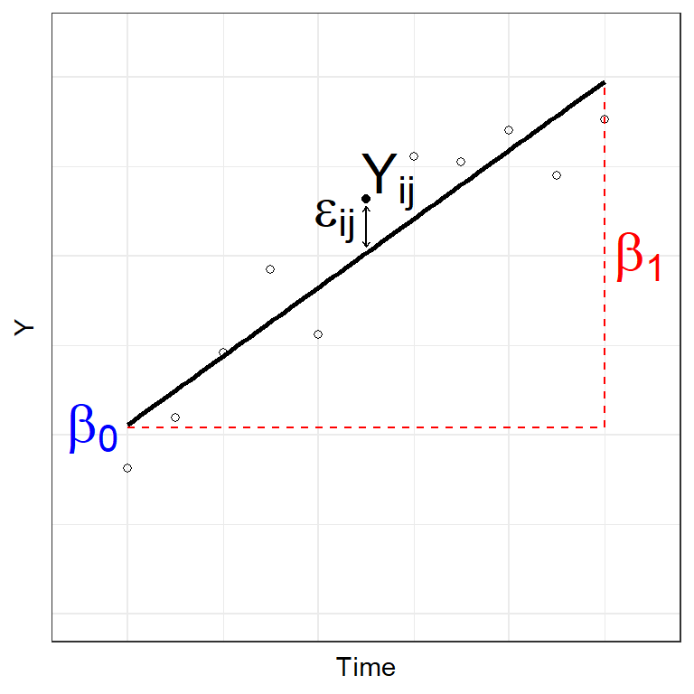

- $Y = \beta_{0} + \beta_{1} \cdot Time$
- $Y_{ij} = \beta_{0i} + \beta_{1i} \cdot Time_{j} + \epsilon_{ij}$
- **Fixed effects**: $\beta_{0}$ (Intercept), $\beta_{1}$ (Slope)
- **Random effects**: $\epsilon_{ij}$ (Residual error)

# Multilevel regression: Fixed effects

Level 1: $Y_{ij} = \beta_{0i} + \beta_{1i} \cdot Time_{j} + \epsilon_{ij}$

Level 2: model of the Level 1 parameter(s)

- $\beta_{0i} = \gamma_{00} + \zeta_{0i}$
  - $\gamma_{00}$ is the population mean
  - $\zeta_{0i}$ is individual deviation from the mean
- $\beta_{0i} = \gamma_{00} + \gamma_{0C} \cdot C + \zeta_{0i}$
  - $\gamma_{0C}$ is the fixed effect of condition $C$ on the *intercept*
- $\beta_{1i} = \gamma_{10} + \gamma_{1C} \cdot C + \zeta_{1i}$
  - $\gamma_{1C}$ is the fixed effect of condition $C$ on the *slope*

# Multilevel regression: Random effects

Level 1: $Y_{ij} = \beta_{0i} + \beta_{1i} \cdot Time_{j} + \epsilon_{ij}$

Level 2:

$\beta_{0i} = \gamma_{00} + \gamma_{0C} \cdot C + \zeta_{0i}$

$\beta_{1i} = \gamma_{10} + \gamma_{1C} \cdot C + \zeta_{1i}$

Residual errors

- $\zeta_{0i}$ unexplained variance in *intercept*
- $\zeta_{1i}$ unexplained variance in *slope*
- Unexplained variance reflects individual differences
- Random effects require a lot of data to estimate

# Fixed vs. Random effects

**Fixed effects**

- Interesting in themselves
- Reproducible fixed properties of the world (nouns vs. verbs, WM load, age, etc.)
- *Unique, unconstrained parameter estimate for each condition*

**Random effects**

- Randomly sampled observational units over which you intend to generalize (particular nouns/verbs, particular individuals, etc.)
- Unexplained variance
- *Drawn from normal distribution with mean 0*

# Maximum Likelihood Estimation

- Find an estimate of parameters that maximizes the likelihood of observing the actual data
- Simple regression: OLS produces MLE parameters by solving an equation
- Multilevel regression: use iterative algorithm to gradually converge to MLE estimates
- Goodness of fit measure: log likelihood (LL)
  - Not inherently meaningful (unlike $R^2$)
  - Change in LL indicates improvement of the fit of the model
  - Changes in $-2LL$ (aka “Likelihood Ratio”") are distributed as $\chi^2$
  - Requires models be nested (parameters added or removed)
  - DF = number of parameters added

# A simple (linear) GCA example

```r
# the psy811 package includes helper functions and example data sets
# to install: devtools::install_github("dmirman/psy811")
library(psy811)
summary(VisualSearchEx)
```

```
##   Participant        Dx        Set.Size          RT
##  0042   :  4   Aphasic:60   Min.   : 1.0   Min.   :  414
##  0044   :  4   Control:72   1st Qu.: 4.0   1st Qu.: 1132
##  0083   :  4                Median :10.0   Median : 1814
##  0166   :  4                Mean   :12.8   Mean   : 2261
##  0186   :  4                3rd Qu.:18.8   3rd Qu.: 2808
##  0190   :  4                Max.   :30.0   Max.   :12201
##  (Other):108
```

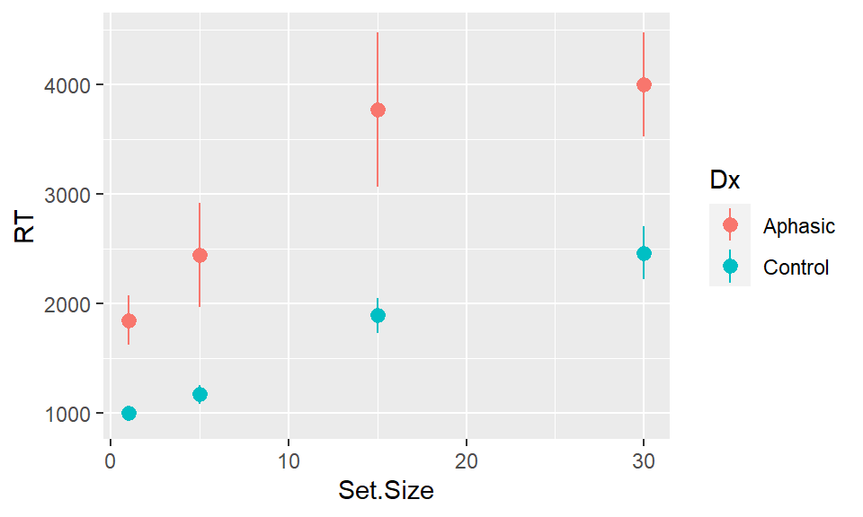

```r
ggplot(VisualSearchEx, aes(Set.Size, RT, color=Dx)) +
  stat_summary(fun.data=mean_se, geom="pointrange")
```

# A simple (linear) GCA example: Fit the models

```r
library(lme4)
library(lmerTest) #for estimated df and p-values
# a null, intercept-only model
vs.null <- lmer(RT ~ 1 + (Set.Size | Participant), data=VisualSearchEx, REML=FALSE)
# add effect of set size
vs <- lmer(RT ~ Set.Size + (Set.Size | Participant), data=VisualSearchEx, REML=F)
# add effect of diagnosis
vs.0 <- lmer(RT ~ Set.Size + Dx + (Set.Size | Participant), data=VisualSearchEx, REML=F)
# add set size by diagnosis interaction
vs.1 <- lmer(RT ~ Set.Size * Dx + (Set.Size | Participant), data=VisualSearchEx, REML=F)
# compare model fits
anova(vs.null, vs, vs.0, vs.1)
```

```
## Data: VisualSearchEx
## Models:
## vs.null: RT ~ 1 + (Set.Size | Participant)
## vs: RT ~ Set.Size + (Set.Size | Participant)
## vs.0: RT ~ Set.Size + Dx + (Set.Size | Participant)
## vs.1: RT ~ Set.Size * Dx + (Set.Size | Participant)
##         npar  AIC  BIC logLik deviance Chisq Df Pr(>Chisq)
## vs.null    5 2283 2297  -1136     2273
## vs         6 2248 2265  -1118     2236 36.90  1    1.2e-09 ***
## vs.0       7 2241 2261  -1114     2227  8.58  1     0.0034 **
## vs.1       8 2241 2264  -1113     2225  2.01  1     0.1566
## ---
## Signif. codes:  0 '***' 0.001 '**' 0.01 '*' 0.05 '.' 0.1 ' ' 1
```

# A simple (linear) GCA example: Interpet results

Model comparisons

|  | npar | AIC | BIC | logLik | deviance | Chisq | Df | Pr(>Chisq) |
| --- | --- | --- | --- | --- | --- | --- | --- | --- |
| vs.null | 5 | 2283 | 2297 | -1136 | 2273 | NA | NA | NA |
| vs | 6 | 2248 | 2265 | -1118 | 2236 | 36.902 | 1 | 0.000 |
| vs.0 | 7 | 2241 | 2261 | -1114 | 2227 | 8.585 | 1 | 0.003 |
| vs.1 | 8 | 2241 | 2264 | -1113 | 2225 | 2.006 | 1 | 0.157 |

- Compared to null model, adding set size (`vs`) substantially improves model fit: response times are affected by number of distractors
- Adding effect of Diagnosis on intercept (`vs.0`) significantly improves model fit: stroke survivors respond more slowly than controls do
- Adding interaction of set size and Diagnosis, i.e., effect of Diagnosis on slope (`vs.1`), does not significantly improve model fit: stroke survivors are not more affected by distractors than controls are

# A simple (linear) GCA example: Inspect model

```r
summary(vs.1)
```

```
## Linear mixed model fit by maximum likelihood . t-tests use Satterthwaite's
##   method [lmerModLmerTest]
## Formula: RT ~ Set.Size * Dx + (Set.Size | Participant)
##    Data: VisualSearchEx
##
##      AIC      BIC   logLik deviance df.resid
##     2241     2264    -1113     2225      124
##
## Scaled residuals:
##    Min     1Q Median     3Q    Max
## -3.759 -0.317 -0.079  0.317  6.229
##
## Random effects:
##  Groups      Name        Variance Std.Dev. Corr
##  Participant (Intercept) 613397   783.2
##              Set.Size       380    19.5    1.00
##  Residual                756827   870.0
## Number of obs: 132, groups:  Participant, 33
##
## Fixed effects:
##                    Estimate Std. Error      df t value Pr(>|t|)
## (Intercept)          2078.7      264.4    35.7    7.86  2.6e-09 ***
## Set.Size               73.5       11.2    54.9    6.54  2.1e-08 ***
## DxControl           -1106.1      357.9    35.7   -3.09   0.0039 **
## Set.Size:DxControl    -21.7       15.2    54.9   -1.43   0.1585
## ---
## Signif. codes:  0 '***' 0.001 '**' 0.01 '*' 0.05 '.' 0.1 ' ' 1
##
## Correlation of Fixed Effects:
##             (Intr) Set.Sz DxCntr
## Set.Size    -0.090
## DxControl   -0.739  0.066
## St.Sz:DxCnt  0.066 -0.739 -0.090
## convergence code: 0
## boundary (singular) fit: see ?isSingular
```

# A simple (linear) GCA example: Plot model fit

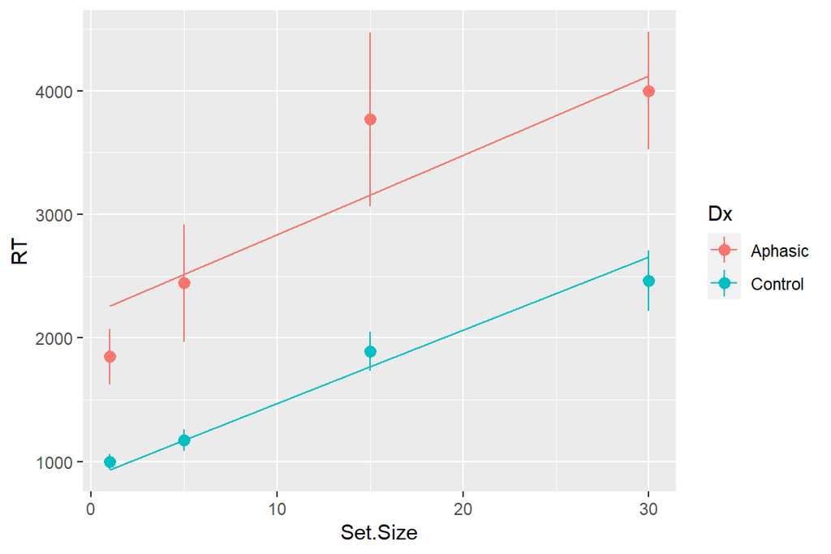

```r
ggplot(VisualSearchEx, aes(Set.Size, RT, color=Dx)) +
  stat_summary(fun.data=mean_se, geom="pointrange") +
  stat_summary(aes(y=fitted(vs.0)), fun=mean, geom="line")
```

# A simple (linear) GCA example: Compare model fits

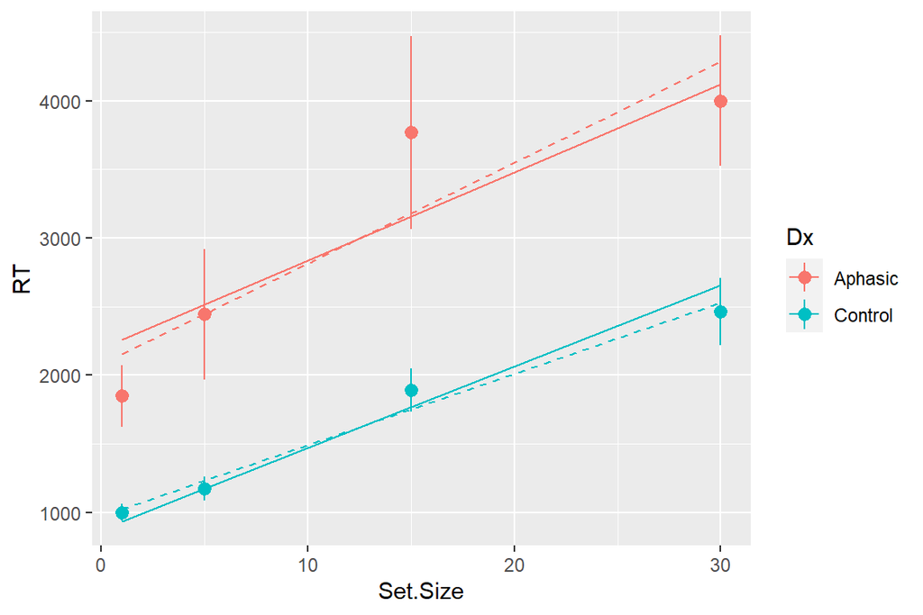

```r
ggplot(VisualSearchEx, aes(Set.Size, RT, color=Dx)) +
  stat_summary(fun.data=mean_se, geom="pointrange") +
  stat_summary(aes(y=fitted(vs.0)), fun=mean, geom="line") +
  stat_summary(aes(y=fitted(vs.1)), fun=mean, geom="line", linetype="dashed")
```

# Practice Exercises

**Exercise 1A**: Analyze the US state-level suicide rate data from the WISQARS (`wisqars.suicide`)

- did the regions differ in their baseline (1999) suicide rates?
- did the regions differ in their rates of change of suidice rate?
- plot observed data and model fits

**Exercise 1B**: Analyze the recovery of object naming ability in aphasia (`NamingRecovery`)

- did the patients recovery any naming ability?
- did recovery differ across aphasia sub-types?